# Chocolate

**Comments to Critiquers:**

## Background

The dataset includes countries from around the world that rated different types of chocolate bars. More detail is listed below:

#### About the dataset:

- Company: Name of the company manufacturing the bar.
- Orig: The specific geo-region of origin for the bar.
- Review: Date of publication of the review.
- Cocoa: Cocoa percentage (darkness) of the chocolate bar being reviewed.
- Location: Manufacturer base country.
- Rating: Expert rating for the bar. 5= Elite (Transcending beyond the ordinary limits) 4= Premium (Superior flavor development, character and style) 3= Satisfactory(3.0) to praiseworthy(3.75) (well made with special qualities) 2= Disappointing (Passable but contains at least one significant flaw) 1= Unpleasant (mostly unpalatable)
- Type: The variety (breed) of cocoa bean used, if provided.
- BroadOrig: The broad geo-region of origin for the bean.

Note this dataset and description come from: © 2018 Kaggle Inc for further details visit:

## Question and Hypothesis

#### Question

I have two questions that I wanted to test. My first question is, “does the type of chocolate (based on cocao percentage) affect the raters rating of the chocolate?” My second question is, “does the U.S. or Europe make better dark chocolate?” In order to test this I want to perform a Kruskal-Wallis test on based on the chocolate type and the ratings for the first question. For the second question, I will use a Kruskal-Wallis test using the chocolate type for very dark chocolate only, and use the rating as well.

#### Hypothesis

The hypothesis is that all of the means of the chocolate types are the same for the first question. My alternative hypothesis is that one chocolate type has significantly different ratings, in this case I think that the very dark chocolate will have a lower rating. For the second question my hypothesis is that the means for the very dark chocolate between Europe and the U.S. is the same. My alternative hypothesis is that the means are different.My $\alpha =.05$ for both questions.

$$H_o: \mu_1 = \mu_2 ...= \mu$$
$$H_a: \mu_i ≠ \mu\ for\ at\ least\ one\ i$$

## Testing the Data for Normality

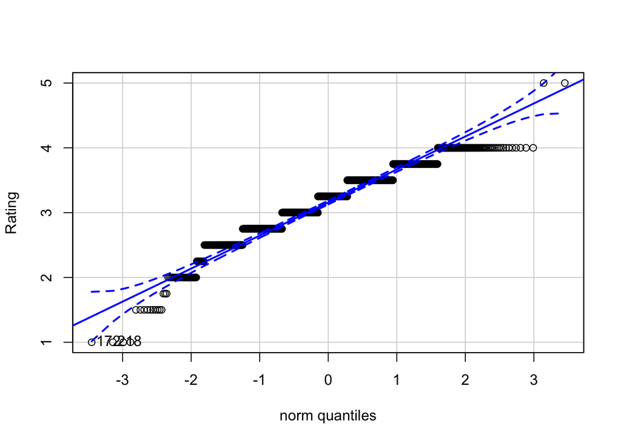

```
## [1] 172 218
```

```r
qqPlot(choc$Rating, ylab = "Rating")
```

#### Explanation

The data does not appear normal, therefore a Kruskal-Wallis test seems appropriate to test the data.

## Analysis

#### Kruskal-Wallis Test

```r
pander(kruskal.test( choc$Rating ~ choc$Cocao, data=choc))
```

Kruskal-Wallis rank sum test: `choc$Rating` by `choc$Cocao`

| Test statistic | df | P value |
| --- | --- | --- |
| 66.16 | 3 | 2.826e-14 * * * |

#### Explanation

The p value was below my $\alpha$ of .05, therefore I reject the null hypothesis and assume that one of the chocolate type’s ratings are different than the others. I will plot the data below to try and be able to visually see if one/multiple chocolate types are different.

#### Boxplot of the Data

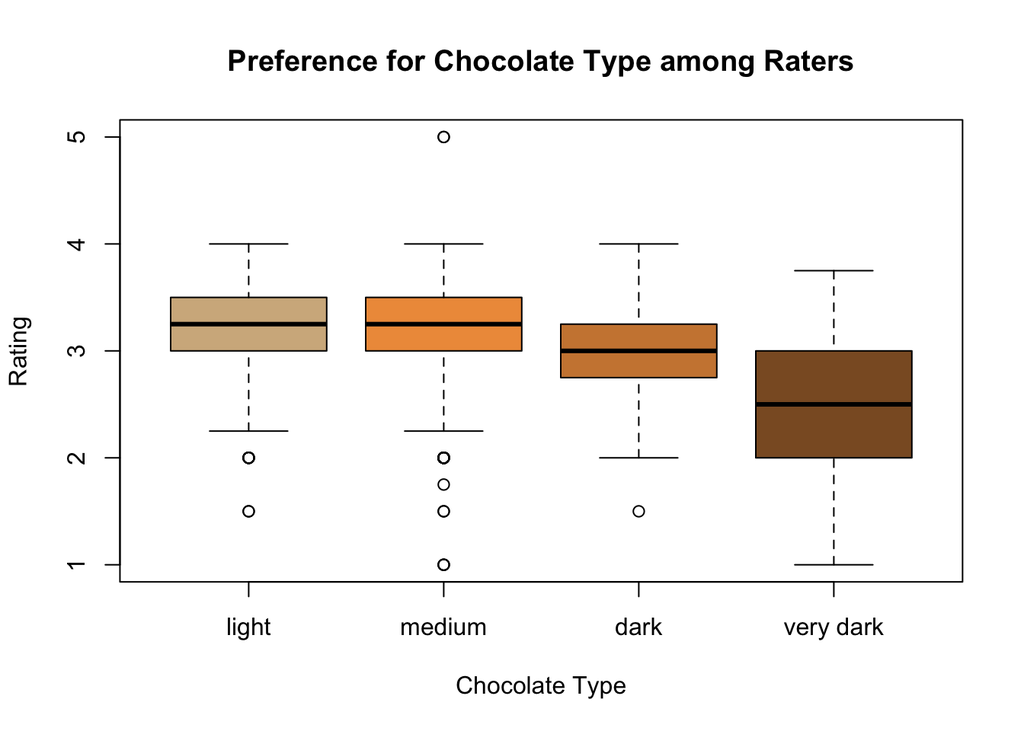

```r
boxplot(choc$Rating ~ choc$Cocao,
        col= c("tan","tan2","tan3","tan4"),
        ylab = "Rating",
        xlab = "Chocolate Type",
        main = "Preference for Chocolate Type among Raters")
```

#### Interpretation

It looks like as the chocolate’s cocao percentage increases, the ratings for the chocolate go down. This confirms my alternative hypothesis that the very dark chocolate would have lower ratings and based off of the Kruskal-Wallis test’s p-value being below the significance level of .05, I can assume the results are significantly different.

## An Extra Boxplot

I want to include one more plot, just out of curiosity, to see if the US or European countries have better “very dark” chocolate. A higher rating for dark chocolate might be more meaningful than light chocolate since it appears that dark chocolate has lower ratings overall.

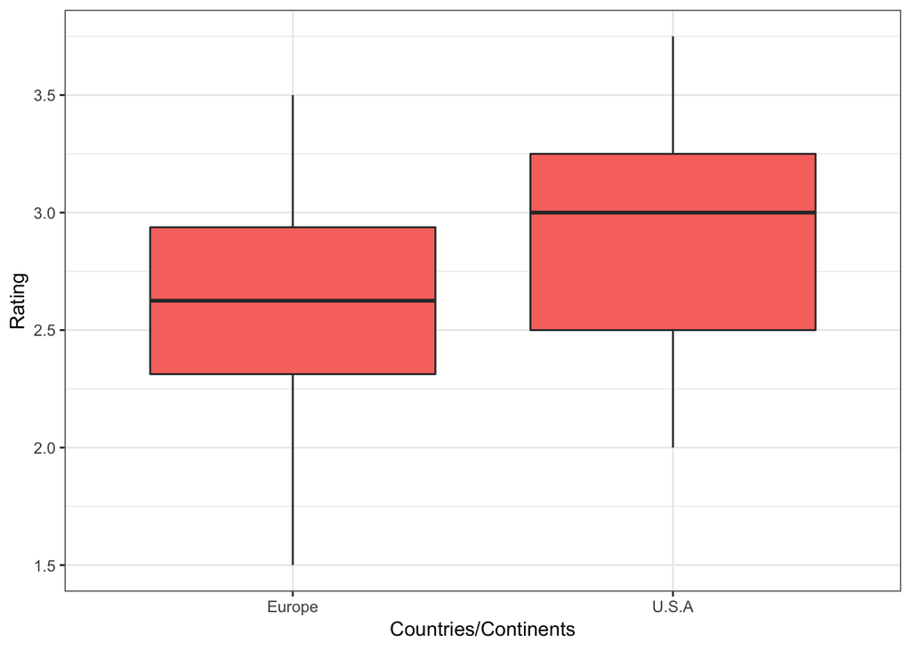

```r
chocnew <- choc %>%
  mutate(Europe = case_when(
    Location == "Amsterdam" |
      Location == "France" |
      Location == "Denmark" |
      Location == "Finland" |
      Location == "Germany" |
      Location == "Iceland" |
      Location == "Italy" |
      Location == "Netherlands" |
      Location == "Portugal" |
      Location == "Scotland" |
      Location == "Spain" |
      Location == "Sweden" |
      Location == "Switzerland" |
      Location == "Denmark" |
      Location == "U.K."
       ~ "Europe",
    Location == "U.S.A." ~ "U.S.A",
    Location == "Canada" ~ "Canada",
    TRUE ~ "Other"
  )
  )
chocEuropeAndUS <- chocnew %>%
  filter(Cocao == "very dark") %>%
  filter(Europe == c("U.S.A","Europe"))

chocEuropeAndUS %>%
  ggplot(aes(x = Europe, y = Rating, fill = "tan")) +
  geom_boxplot() +
  theme_bw() +
  labs(x = "Countries/Continents") +
  guides(fill = FALSE)
```

```r
pander(kruskal.test(chocEuropeAndUS$Rating ~ as.factor(chocEuropeAndUS$Europe), data = chocEuropeAndUS))
```

Kruskal-Wallis rank sum test: `chocEuropeAndUS$Rating` by `as.factor(chocEuropeAndUS$Europe)`

| Test statistic | df | P value |
| --- | --- | --- |
| 0.5382 | 1 | 0.4632 |

#### Interpretation

According to this kruskal-wallis test for the second question, there is not a significant difference in ratings for very dark chocolate between Europe and the U.S.

## Conclusion

Overall, it was interesting to see how the ratings followed a pattern based on cocoa percentage and also that there is no significant difference in the rating of very dark chocolate between Europe and the U.S. The fact that very dark chocolate had such a low overall rating might confirm the widely-held belief that “very dark” chocolate is an acquired taste. On the contrary, if the experts who rated the chocolate can assume to be unbiased by chocolate cocao percentage, then it might show that making dark chocolate is more difficult to perfect and its flaws are more apparent in taste testing. In conclusion, the very dark chocolate appears to have a significantly lower rating than other chocolate types.